# Assessment 3

Dieter Haage

December 3, 2018

Initial Setup

```r
Stamps <- read.table("C:/Users/dieterhaage/Desktop/Stamps_withoutdupl_09.csv", header=FALSE, sep=",", dec=".")
summary(Stamps) # 9 Predictors (V1 to V9) and class labels (V10)
```

```
##        V1                V2               V3                V4
##  Min.   :0.00000   Min.   :0.0000   Min.   :0.00000   Min.   :0.0000
##  1st Qu.:0.04883   1st Qu.:0.3357   1st Qu.:0.04662   1st Qu.:0.2369
##  Median :0.07872   Median :0.4252   Median :0.09584   Median :0.3456
##  Mean   :0.10265   Mean   :0.4197   Mean   :0.14193   Mean   :0.3841
##  3rd Qu.:0.12214   3rd Qu.:0.4416   3rd Qu.:0.19458   3rd Qu.:0.5233
##  Max.   :1.00000   Max.   :0.8645   Max.   :1.00000   Max.   :1.0000
##        V5               V6                V7               V8
##  Min.   :0.0000   Min.   :0.00000   Min.   :0.0000   Min.   :0.000656
##  1st Qu.:0.4524   1st Qu.:0.01010   1st Qu.:0.9183   1st Qu.:0.018221
##  Median :0.5783   Median :0.01945   Median :0.9724   Median :0.032162
##  Mean   :0.5986   Mean   :0.04151   Mean   :0.9299   Mean   :0.054981
##  3rd Qu.:0.7373   3rd Qu.:0.04528   3rd Qu.:0.9884   3rd Qu.:0.059360
##  Max.   :1.0000   Max.   :1.00000   Max.   :1.0000   Max.   :1.000000
##        V9          V10
##  Min.   :0.0000   no :309
##  1st Qu.:0.4492   yes: 31
##  Median :0.5787
##  Mean   :0.5693
##  3rd Qu.:0.7247
##  Max.   :1.0000
```

```r
PB_Predictors <- Stamps[,1:9] # 9 Predictors (V1 to V9)
PB_class <- Stamps[,10] # Class labels (V10)
PB_class <- ifelse(PB_class == 'no',0,1) # Inliers (class "no") = 0, Outliers (class "yes") = 1
```

# ACTIVITY 1: PRINCIPLE COMPONENT ANALYSIS

**1. Perform PCA on Stamps Data**

```r
PCA <- prcomp(PB_Predictors, scale = TRUE) #  calculate PC for variables
PCA$rotation
```

```
##           PC1         PC2        PC3         PC4         PC5         PC6
## V1 -0.3570003 -0.10417655  0.1813733 -0.01930228  0.68124006  0.44187577
## V2  0.1420765 -0.30721615  0.1299597  0.92287473  0.06310383 -0.10282233
## V3 -0.3317113 -0.04657823 -0.4767126  0.17893590 -0.46295498  0.39982667
## V4 -0.4230165 -0.22831476 -0.3981637  0.02135029 -0.06765320 -0.08319882
## V5 -0.3853972 -0.33542901 -0.1876273 -0.07414299  0.26797160 -0.51370341
## V6 -0.3966169  0.39119428  0.1187845  0.11471184  0.04270746 -0.39846576
## V7  0.2747583 -0.64007315 -0.1336053 -0.23489388  0.10043151  0.09738610
## V8  0.1884198  0.40303353 -0.5625883  0.19360251  0.45311956  0.20043999
## V9  0.3828311  0.05284966 -0.4251531 -0.06436384  0.15488411 -0.39378111
##            PC7          PC8         PC9
## V1 -0.39311729  0.109611082  0.05031087
## V2 -0.03739759 -0.006920782  0.02905519
## V3 -0.31137242  0.026120489 -0.39585520
## V4  0.12867762 -0.063683586  0.76014917
## V5  0.26148066  0.279863425 -0.46460688
## V6 -0.26188791 -0.651400166 -0.09427161
## V7 -0.04026264 -0.635461942 -0.12955785
## V8  0.40078359 -0.181465084 -0.09499376
## V9 -0.65676748  0.209314272  0.10742798
```

```r
# The variable rotation stores the resulting (rotated) coordinates system.

# Each column represents a vector along the corresponding coordinate direction and, therefore, the columns of rotation are orthogonal.

# sdev^2, returns the respective variances and, by dividing these by the total sum of variances,

# we get the Proportion of the Variance Explained (PVE) by each component:
(PVE <- (PCA$sdev^2)/sum(PCA$sdev^2)) # PVE for each of the 9-dimensional space of the numerical predictors
```

```
## [1] 0.39850879 0.15249102 0.13791734 0.10016372 0.07854404 0.06277860
## [7] 0.03288279 0.02197946 0.01473424
```

Accumulated sum of PVE for the first *m* components (Scree Plot)

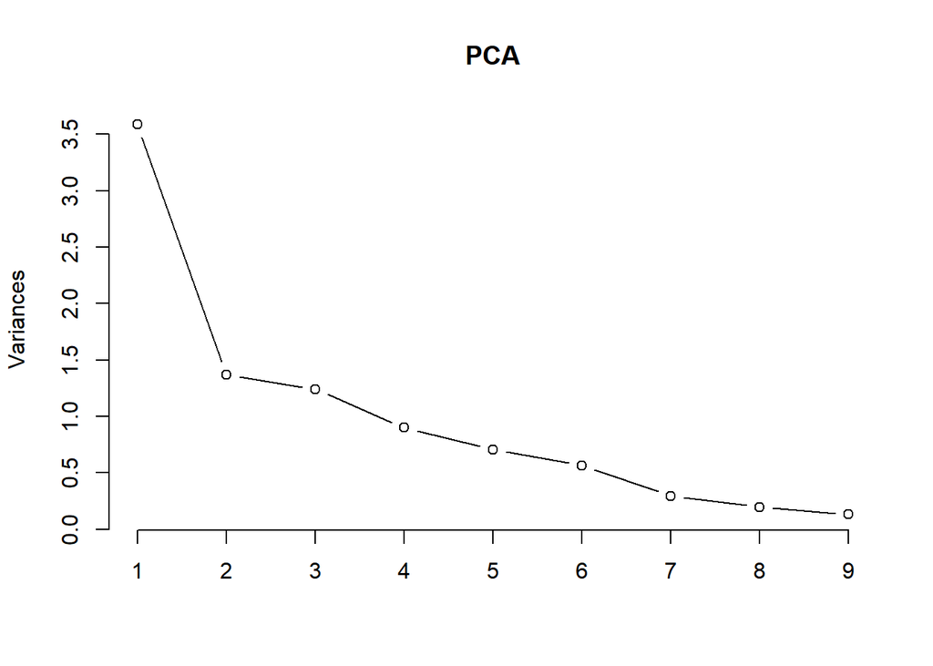

```r
screeplot(PCA, type="lines") # screeplot
```

Accumulated sum of PVE for the first *m* components (Pareto Plot)

```r
library (qcc)
```

```
## Package 'qcc' version 2.7
```

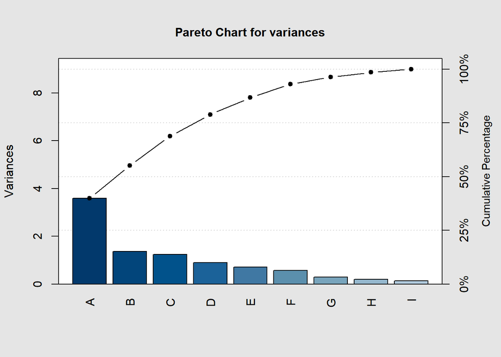

```
##
## Pareto chart analysis for variances
##       Frequency   Cum.Freq.  Percentage Cum.Percent.
##   A   3.5865791   3.5865791  39.8508787   39.8508787
##   B   1.3724191   4.9589982  15.2491015   55.0999802
##   C   1.2412560   6.2002543  13.7917337   68.8917139
##   D   0.9014735   7.1017277  10.0163721   78.9080860
##   E   0.7068964   7.8086241   7.8544040   86.7624899
##   F   0.5650074   8.3736315   6.2778603   93.0403503
##   G   0.2959451   8.6695767   3.2882792   96.3286295
##   H   0.1978152   8.8673918   2.1979461   98.5265756
##   I   0.1326082   9.0000000   1.4734244  100.0000000
```

```r
variances <- PCA$sdev^2  # variances
pareto.chart (variances, ylab="Variances")  #  plot pareto chart
```

1. We need at least 6 out of the 9 components to explain to be able to explain 90% of the variance in the data.
2. The first three Principle Components explain 68.9% of the data.

**2. 3D Scatter-plot represented by first 3 PC’s**

```r
library('plot3D')
#View(PCA$x)
pca_classes <- as.data.frame(PCA$x)
pca_classes$PB_class <- PB_class
```

Plot 3D Scatter of Stamps

```r
library('rgl')
library('RColorBrewer')
plot3d(pca_classes$PC1,
       pca_classes$PC2,
       pca_classes$PC3,
       xlab = "PC1",
       ylab = "PC2",
       zlab = "PC3",
       col = brewer.pal(3, "Dark2")[unclass(pca_classes$PB_class)],
       size = 8)
```

Plot 3d Scatter of Data Colored by Inliers and Outliers

```r
pca_classes$PB_class <- as.factor(pca_classes$PB_class)
plot3d(pca_classes$PC1,
       pca_classes$PC2,
       pca_classes$PC3,
       xlab = "PC1",
       ylab = "PC2",
       zlab = "PC3",
       col = brewer.pal(3, "Dark2")[unclass(pca_classes$PB_class)],
       size = 8)
```

Three different angles of 3d plot. Inliers (class “no”) = 0, Outliers (class “yes”) = 1. Outliers in Red.

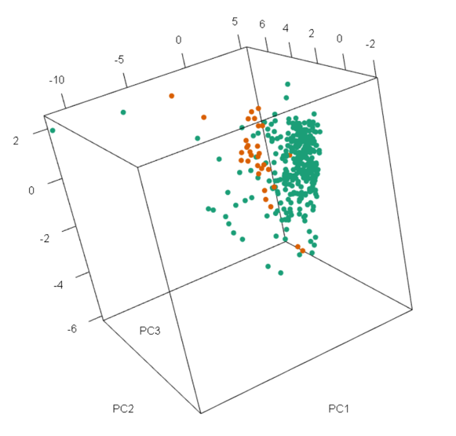

```r
knitr::include_graphics('C:/Users/dieterhaage/Desktop/A3/a_ro1.png')
```

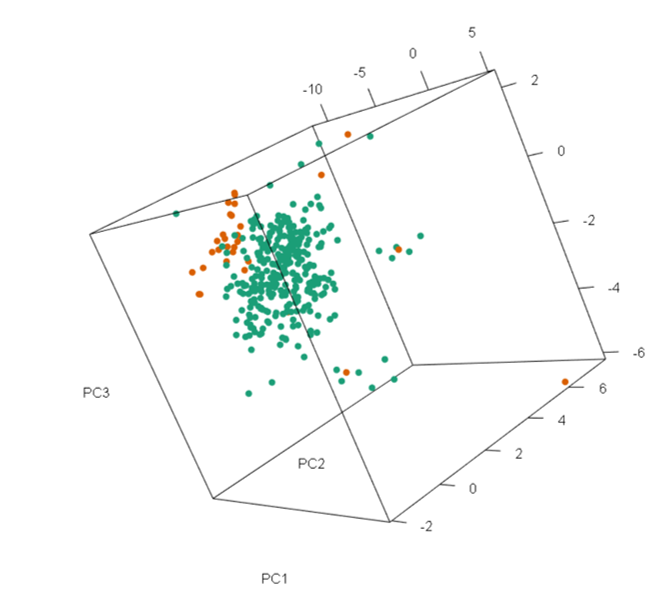

```r
knitr::include_graphics('C:/Users/dieterhaage/Desktop/A3/a_ro2.png')
```

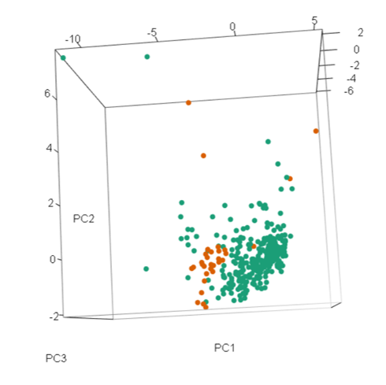

```r
knitr::include_graphics('C:/Users/dieterhaage/Desktop/A3/a_ro3.png')
```

Recalling that class labels would not be available in a practical application of **unsupervised** learning, the outliers in this case do seem reasonably easy to detect in an unsupervised way. So in the case of **supervised** learning, since there is somewhat of a large separation between outleirs and the rest of the group, we can assume that a supervised strategy may also be applicable in this case, and should be able to detect the outliers as well.

# ACTIVITY 2: Unsupervised Outlier Detection

KNN Outlier K = 5, Diverging Color KNN Outlier Scores

```r
library(dbscan)
k <- 5 # KNN parameter
KNN_Outlier <- kNNdist(x=PB_Predictors, k = k)[,k] # KNN distance (outlier score) computation
top_n <- 20 # No. of top outliers to be displayed
rank_KNN_Outlier <- order(x=KNN_Outlier, decreasing = TRUE) # Sorting (descending)
KNN_Result <- data.frame(ID = rank_KNN_Outlier, score = KNN_Outlier[rank_KNN_Outlier])
head(KNN_Result, top_n)
```

```
##     ID     score
## 1  150 1.0831392
## 2  271 0.9452268
## 3   22 0.8701538
## 4    2 0.8176631
## 5  130 0.7382603
## 6  328 0.6434083
## 7   19 0.6400374
## 8  199 0.4853853
## 9  197 0.4831582
## 10  88 0.4626465
## 11 116 0.4620797
## 12 191 0.4619196
## 13 276 0.4239779
## 14  49 0.4228653
## 15 186 0.4188267
## 16 273 0.4150218
## 17 188 0.3989988
## 18 102 0.3716263
## 19 149 0.3706868
## 20 238 0.3685038
```

```r
knn_distance <- pca_classes
knn_distance$score <- KNN_Result$score


library(rgl)

myColorRamp <- function(colors, values) {
    v <- (values - min(knn_distance$score))/diff(range(knn_distance$score))
    x <- colorRamp(colors)(v)
    rgb(x[,1], x[,2], x[,3], maxColorValue = 275)
}

x <- knn_distance$PC1
y <- knn_distance$PC2
z <- knn_distance$PC3

cols <- myColorRamp(c("red", "blue"), knn_distance$score)
#plot3d(x = x, y = y, z = z, col = cols)
plot3d(x = x, y = y, z = z, col = heat.colors(length(knn_distance$score))[rank(knn_distance$score)])
```

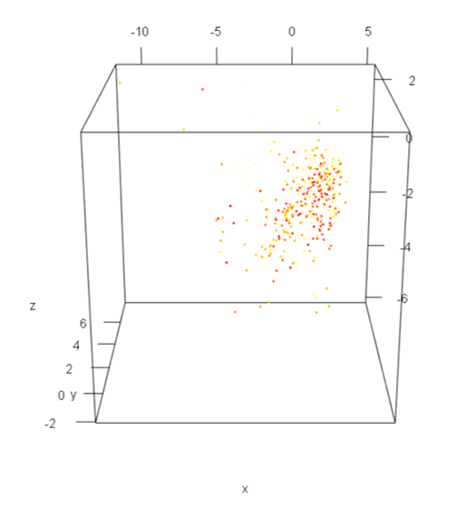

```r
knitr::include_graphics('C:/Users/dieterhaage/Desktop/A3/k = 5 div.png')
```

Top 31 outliers for K = 5

```r
top_31 <- KNN_Result
top_31$rank <-  rank(top_31$score)
top_31$rank <-  order(top_31$score, decreasing = T)
top_31$top_31 <- "FALSE"
top_31$top_31[top_31$rank <= 31] <- "TRUE"

pca_top31 <- pca_classes
pca_top31$ID <- 1:nrow(pca_top31)
pca_top31$distance_score <- top_31$score[match(pca_top31$ID, top_31$ID)]
pca_top31$rank <- top_31$rank[match(pca_top31$ID, top_31$ID)]
pca_top31$top_31_dist <- top_31$top_31[match(pca_top31$ID, top_31$ID)]
```

K = 5 top 31 Outliers Plot

```r
pca_top31$top_31_dist <- as.factor(pca_top31$top_31_dist)
mycols <- colors()[c(24, 36)]
plot3d(pca_top31$PC1,
       pca_top31$PC2,
       pca_top31$PC3,
       xlab = "PC1",
       ylab = "PC2",
       zlab = "PC3",
       col = mycols[unclass(pca_top31$top_31_dist)],
       size = 8)
```

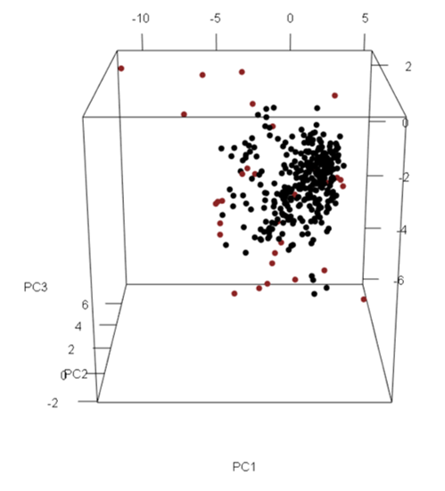

```r
knitr::include_graphics('C:/Users/dieterhaage/Desktop/A3/top_31_k5.png')
```

KNN Outlier K = 25, Diverging Color KNN Outlier Scores

```r
library(dbscan)
k <- 25 # KNN parameter
KNN_Outlier <- kNNdist(x=PB_Predictors, k = k)[,k] # KNN distance (outlier score) computation
top_n <- 20 # No. of top outliers to be displayed
rank_KNN_Outlier <- order(x=KNN_Outlier, decreasing = TRUE) # Sorting (descending)
KNN_Result <- data.frame(ID = rank_KNN_Outlier, score = KNN_Outlier[rank_KNN_Outlier])
head(KNN_Result, top_n)
```

```
##     ID     score
## 1  150 1.2963491
## 2  271 1.0615617
## 3   22 1.0096438
## 4    2 0.9969271
## 5  328 0.9158535
## 6  130 0.8550355
## 7   19 0.7513259
## 8  199 0.5966591
## 9  276 0.5925294
## 10 197 0.5920398
## 11  88 0.5896104
## 12 171 0.5894291
## 13 238 0.5829931
## 14 169 0.5788086
## 15 116 0.5686392
## 16 179 0.5632258
## 17 273 0.5522833
## 18 198 0.5520698
## 19 334 0.5477680
## 20  24 0.5399514
```

```r
knn_distance <- pca_classes
knn_distance$score <- KNN_Result$score

library(rgl)

myColorRamp <- function(colors, values) {
    v <- (values - min(knn_distance$score))/diff(range(knn_distance$score))
    x <- colorRamp(colors)(v)
    rgb(x[,1], x[,2], x[,3], maxColorValue = 275)
}

x <- knn_distance$PC1
y <- knn_distance$PC2
z <- knn_distance$PC3



cols <- myColorRamp(c("red", "blue"), knn_distance$score)
plot3d(x = x, y = y, z = z, col = heat.colors(length(knn_distance$score))[rank(knn_distance$score)])
```

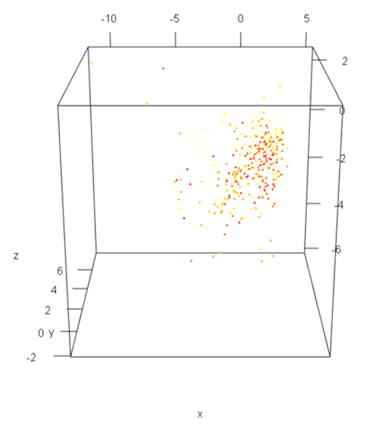

```r
knitr::include_graphics('C:/Users/dieterhaage/Desktop/A3/k25div.png')
```

Plot Outliers for K = 25

```r
top_31 <- KNN_Result
top_31$rank <-  rank(top_31$score)
top_31$rank <-  order(top_31$score, decreasing = T)
top_31$top_31 <- "FALSE"
top_31$top_31[top_31$rank <= 31] <- "TRUE"

pca_top31 <- pca_classes
pca_top31$ID <- 1:nrow(pca_top31)
pca_top31$distance_score <- top_31$score[match(pca_top31$ID, top_31$ID)]
pca_top31$rank <- top_31$rank[match(pca_top31$ID, top_31$ID)]
pca_top31$top_31_dist <- top_31$top_31[match(pca_top31$ID, top_31$ID)]
```

K = 25 Top 31 KNN Outliers Plot

```r
pca_top31$top_31_dist <- as.factor(pca_top31$top_31_dist)
mycols <- colors()[c(24, 36)]
plot3d(pca_top31$PC1,
       pca_top31$PC2,
       pca_top31$PC3,
       xlab = "PC1",
       ylab = "PC2",
       zlab = "PC3",
       col = mycols[unclass(pca_top31$top_31_dist)],
       size = 8)
```

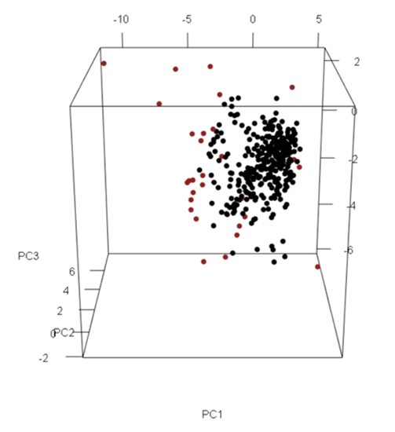

```r
knitr::include_graphics('C:/Users/dieterhaage/Desktop/A3/31k25.png')
```

KNN Outlier K = 100, Diverging Color KNN Outlier Scores

```r
library(dbscan)
k <- 100 # KNN parameter
KNN_Outlier <- kNNdist(x=PB_Predictors, k = k)[,k] # KNN distance (outlier score) computation
top_n <- 20 # No. of top outliers to be displayed
rank_KNN_Outlier <- order(x=KNN_Outlier, decreasing = TRUE) # Sorting (descending)
KNN_Result <- data.frame(ID = rank_KNN_Outlier, score = KNN_Outlier[rank_KNN_Outlier])
head(KNN_Result, top_n)
```

```
##     ID     score
## 1  150 1.5027937
## 2  271 1.1867804
## 3   22 1.1317200
## 4    2 1.1002580
## 5  328 1.0519702
## 6  130 1.0366054
## 7   19 0.8689258
## 8  238 0.8155971
## 9  169 0.8117624
## 10 171 0.8028156
## 11  88 0.7894132
## 12 334 0.7701768
## 13 179 0.7664834
## 14  16 0.7528911
## 15 199 0.7516090
## 16 116 0.7475236
## 17 198 0.7337230
## 18 276 0.7317956
## 19 149 0.7125346
## 20  25 0.7076002
```

```r
knn_distance <- pca_classes
knn_distance$score <- KNN_Result$score

library(rgl)

myColorRamp <- function(colors, values) {
    v <- (values - min(knn_distance$score))/diff(range(knn_distance$score))
    x <- colorRamp(colors)(v)
    rgb(x[,1], x[,2], x[,3], maxColorValue = 275)
}

x <- knn_distance$PC1
y <- knn_distance$PC2
z <- knn_distance$PC3



cols <- myColorRamp(c("red", "blue"), knn_distance$score)
plot3d(x = x, y = y, z = z, col = heat.colors(length(knn_distance$score))[rank(knn_distance$score)])
```

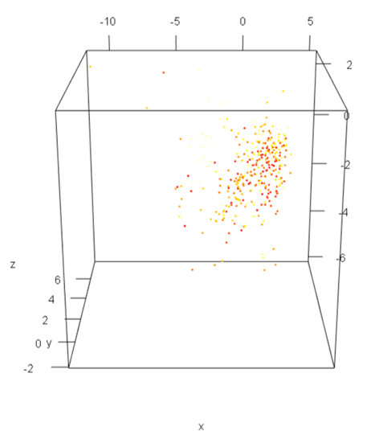

```r
knitr::include_graphics('C:/Users/dieterhaage/Desktop/A3/100div.png')
```

Label Outliers

```r
top_31 <- KNN_Result
top_31$rank <-  rank(top_31$score)
top_31$rank <-  order(top_31$score, decreasing = T)
top_31$top_31 <- "FALSE"
top_31$top_31[top_31$rank <= 31] <- "TRUE"

pca_top31 <- pca_classes
pca_top31$ID <- 1:nrow(pca_top31)
pca_top31$distance_score <- top_31$score[match(pca_top31$ID, top_31$ID)]
pca_top31$rank <- top_31$rank[match(pca_top31$ID, top_31$ID)]
pca_top31$top_31_dist <- top_31$top_31[match(pca_top31$ID, top_31$ID)]
```

K = 100 Top 31 Outliers

```r
pca_top31$top_31_dist <- as.factor(pca_top31$top_31_dist)
mycols <- colors()[c(24, 36)]
plot3d(pca_top31$PC1,
       pca_top31$PC2,
       pca_top31$PC3,
       xlab = "PC1",
       ylab = "PC2",
       zlab = "PC3",
       col = mycols[unclass(pca_top31$top_31_dist)],
       size = 8)
```

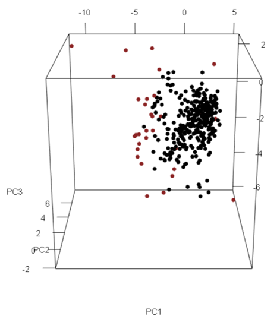

```r
knitr::include_graphics('C:/Users/dieterhaage/Desktop/A3/100k31.png')
```

These plots do provide some new insights into the value of k, the diverging color scale for KNN outliers scores shows us that potential outliers are different to the rest of the cluster, and the further they are from the center of the cluster the higher the KNN outlier score.

From an **unsupervised** perspective, we can say that the top 31 outliers change for each new value of k, and therefore it is important to note that what may be considered an outlier for one measure of k, may not be the same for another.

# ACTIVITY 3: Supervised Anomoly Detection

## 2. Supervised Classification on Stamps

ROCR Function

```r
library(ROCR)
```

```r
rocplot <- function(pred, truth){
  predobj <<- prediction(pred, truth)
  ROC     <<- performance(predobj, "tpr", "fpr")
  plot(ROC)   # Plot the ROC Curve
  auc     <- performance(predobj, measure = "auc")
  auc     <- auc@y.values[[1]]
  return(auc) # Return the Area Under the Curve ROC
}

#AUC <- rocplot(pred=P_positive_test, truth=test_class_labels)
```

Scale Predictors as Matrix for KNN

```r
predictors <- Stamps[,1:9]
predictors <- as.matrix(scale(predictors)) # Variable scaling required by KNN
class_labels <- Stamps[,10]
```

KNN for k = 5, Stamps Data

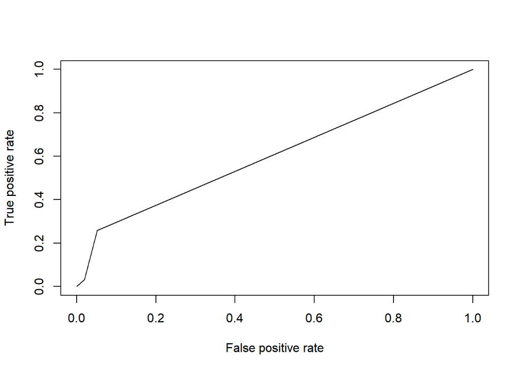

```r
library(class)

k = 5
Pred_class <- knn.cv(train=predictors, cl=class_labels, k=k, prob=TRUE)
Pred_prob_5 <- attr(Pred_class, "prob")
Pred_prob_5 <- ifelse(Pred_class=='+', Pred_prob, 1 - Pred_prob_5) # Make sure probabilities are for class "+"

AUC <- rocplot(pred=Pred_prob_5, truth=class_labels)
```

KNN for k = 25, Stamps Data

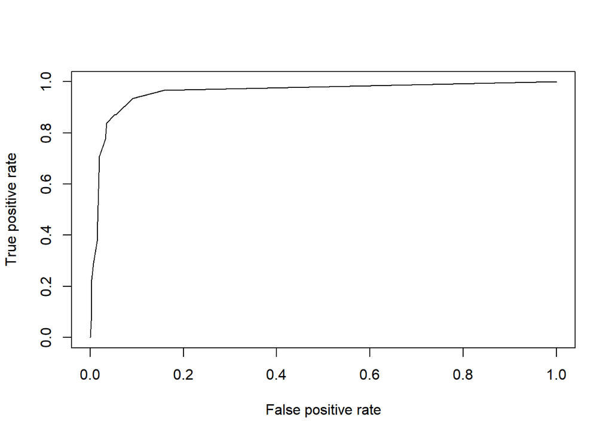

```r
k = 25
Pred_class <- knn.cv(train=predictors, cl=class_labels, k=k, prob=TRUE)
Pred_prob_25 <- attr(Pred_class, "prob")
Pred_prob_25 <- ifelse(Pred_class=='+', Pred_prob, 1 - Pred_prob_25) # Make sure probabilities are for class "+"

AUC <- rocplot(pred=Pred_prob_25, truth=class_labels)
```

KNN for k = 100, Stamps Data

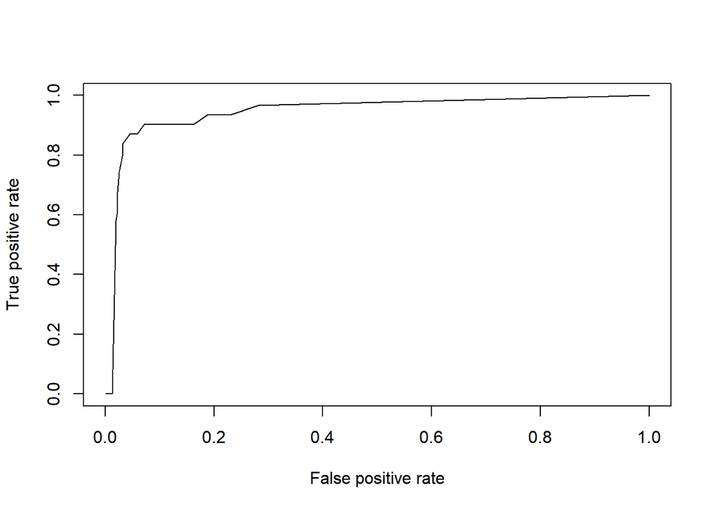

```r
k = 100
Pred_class <- knn.cv(train=predictors, cl=class_labels, k=k, prob=TRUE)
Pred_prob_100 <- attr(Pred_class, "prob")
Pred_prob_100 <- ifelse(Pred_class=='+', Pred_prob, 1 - Pred_prob_100) # Make sure probabilities are for class "+"

AUC <- rocplot(pred=Pred_prob_100, truth=class_labels)
```

Compare all AUC-ROC of KNN Classifiers

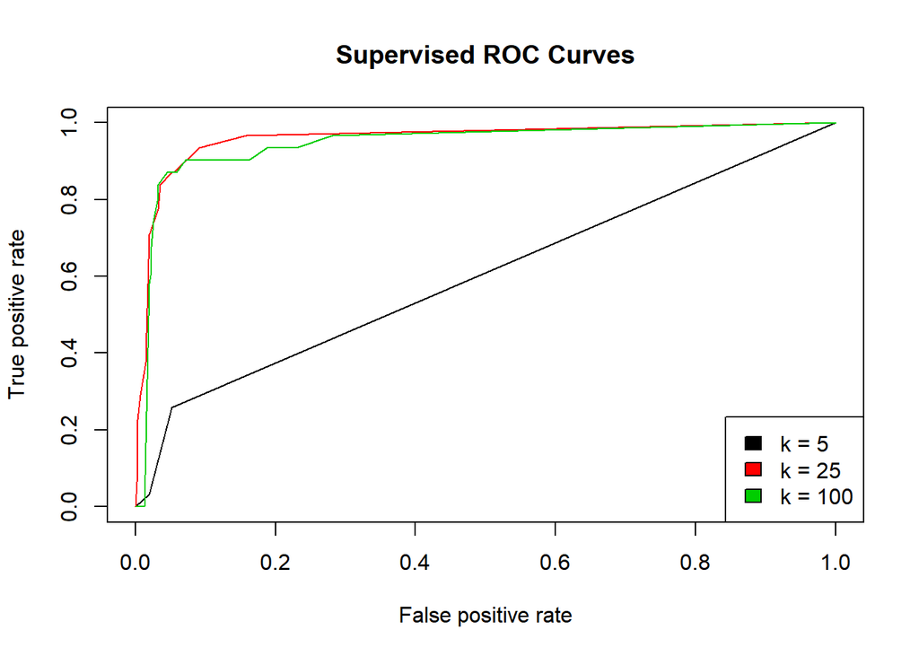

```r
pred5 <- Pred_prob_5
pred25 <- Pred_prob_25
pred100 <- Pred_prob_100


# RUN ALL AT ONCE
class_label<- as.list(class_labels)

# List of predictions
preds_list <- list(pred5, pred25, pred100)

# List of actual values (same for all)
m <- length(preds_list)
actuals_list <- rep(list(class_labels), m)

# Plot the ROC curves
pred <- prediction(preds_list, actuals_list)
rocs <- performance(pred, "tpr", "fpr")
plot(rocs, col = as.list(1:m), main = "Supervised ROC Curves")
legend(x = "bottomright",
       legend = c("k = 5 ", "k = 25", "k = 100"),
       fill = 1:m)
```

## 2. Supervised KNN performance vs. Unsepervised Outlier

k unsupervised = 5

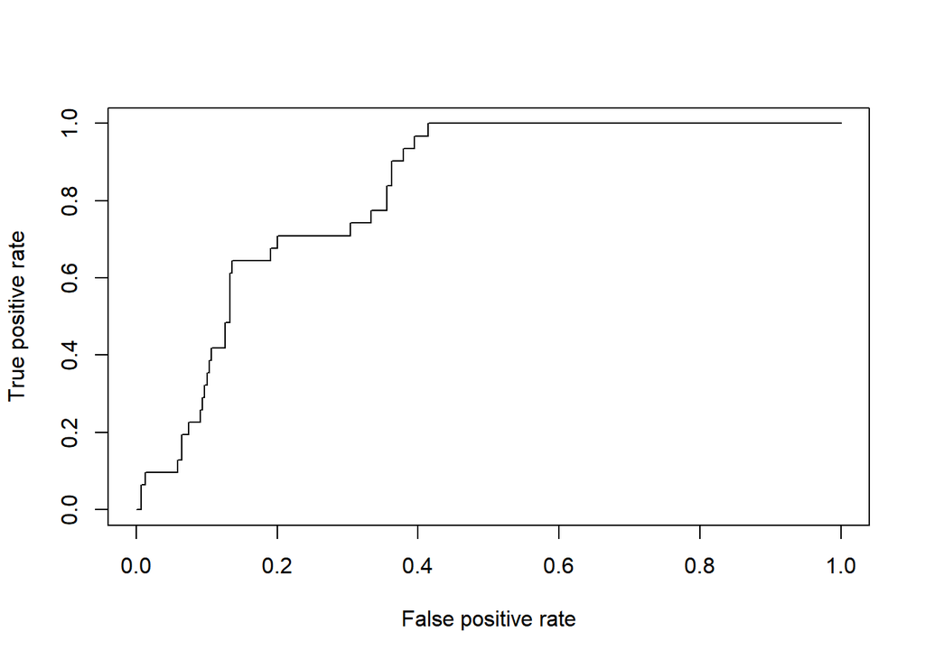

```r
library(dbscan)
k <- 5 # KNN parameter
KNN_Outlier <- kNNdist(x=PB_Predictors, k = k)[,k] # KNN distance (outlier score) computation
top_n <- 20 # No. of top outliers to be displayed
rank_KNN_Outlier <- order(x=KNN_Outlier, decreasing = TRUE) # Sorting (descending)
KNN_Result <- data.frame(ID = rank_KNN_Outlier, score = KNN_Outlier[rank_KNN_Outlier])

Pred_prob <- (KNN_Outlier-min(KNN_Outlier))/(max(KNN_Outlier)-min(KNN_Outlier))

pred5_un <- Pred_prob

AUC <- rocplot(pred=Pred_prob, truth=PB_class)
```

k unsupervised = 25

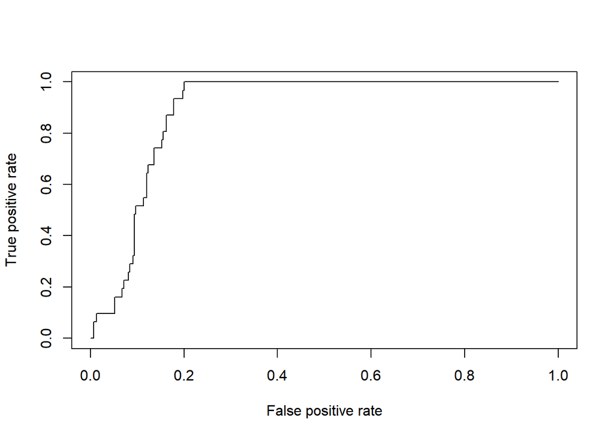

```r
library(dbscan)
k <- 25 # KNN parameter
KNN_Outlier <- kNNdist(x=PB_Predictors, k = k)[,k] # KNN distance (outlier score) computation
top_n <- 20 # No. of top outliers to be displayed
rank_KNN_Outlier <- order(x=KNN_Outlier, decreasing = TRUE) # Sorting (descending)
KNN_Result <- data.frame(ID = rank_KNN_Outlier, score = KNN_Outlier[rank_KNN_Outlier])

Pred_prob <- (KNN_Outlier-min(KNN_Outlier))/(max(KNN_Outlier)-min(KNN_Outlier))

pred25_un <- Pred_prob

AUC <- rocplot(pred=Pred_prob, truth=PB_class)
```

k unsupervised = 100

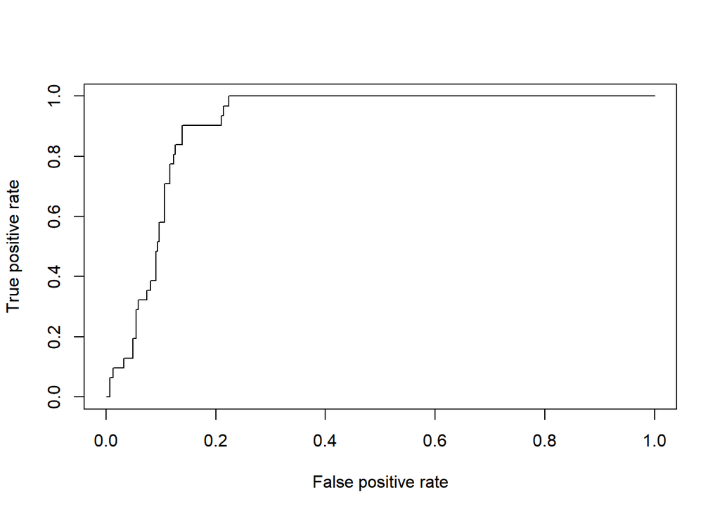

```r
library(dbscan)
k <- 100 # KNN parameter
KNN_Outlier <- kNNdist(x=PB_Predictors, k = k)[,k] # KNN distance (outlier score) computation
top_n <- 20 # No. of top outliers to be displayed
rank_KNN_Outlier <- order(x=KNN_Outlier, decreasing = TRUE) # Sorting (descending)
KNN_Result <- data.frame(ID = rank_KNN_Outlier, score = KNN_Outlier[rank_KNN_Outlier])

Pred_prob <- (KNN_Outlier-min(KNN_Outlier))/(max(KNN_Outlier)-min(KNN_Outlier))

pred100_un <- Pred_prob

AUC <- rocplot(pred=Pred_prob, truth=PB_class)
```

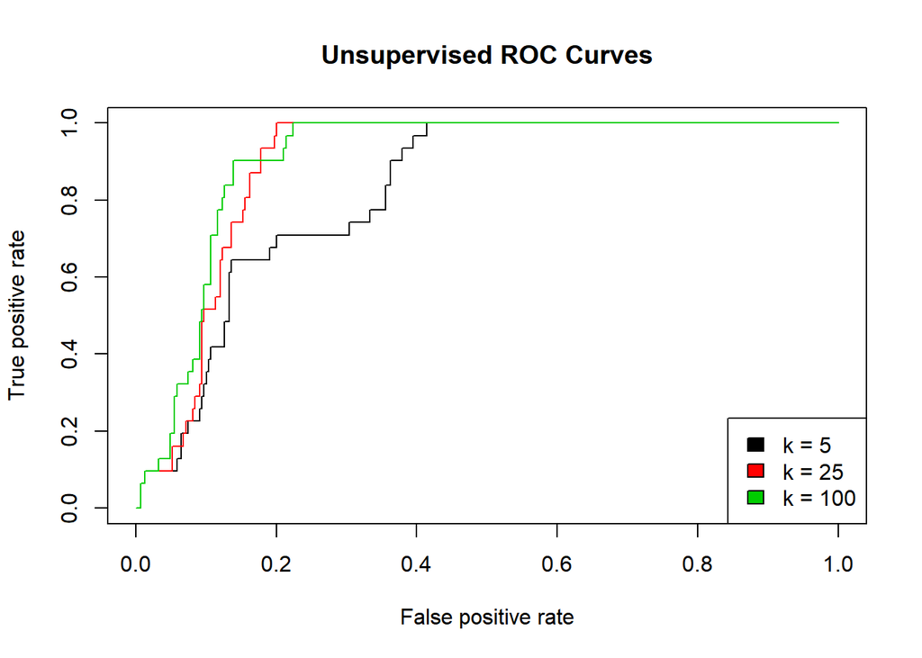

```r
# RUN ALL AT ONCE
class_label<- as.list(PB_class)

# List of predictions
preds_list_un <- list(pred5_un, pred25_un, pred100_un)

# List of actual values (same for all)
m <- length(preds_list_un)
actuals_list <- rep(list(PB_class), m)

# Plot the ROC curves
pred <- prediction(preds_list_un, actuals_list)
rocs <- performance(pred, "tpr", "fpr")
plot(rocs, col = as.list(1:m), main = "Unsupervised ROC Curves")
legend(x = "bottomright",
       legend = c("k = 5 ", "k = 25", "k = 100"),
       fill = 1:m)
```

The performances by the Supervised classifiers were different to that of the Unsupervised classifiers.

Overall, it seems that other than for where k = 5, the Supervised classification true positive rate seemed to outperform the Unsupervised classification for the same measures of k.

Where k = 5, there was a fairly low performance for both Supervised and Unsupervised classifiers. However, while comparing the best performing measure of k. 25 appears to be the optimal choice for k in terms of Supervised classification, while this is untrue for Unsupervised classification.

The highest true positive rate for Unsupervised is attained where k = 100. We can say, that based on this investigation, When the applications of class labels is unavailable, a higher measure of k is optimal for Unsupervised classification when using KNN.